# RADseq data assembly in `ipyrad`

Nathan W. Byer (modified from Todd W. Pierson)

**Note:** This tutorial represents an updated version of Todd Pierson’s “RADseq data assembly in ‘ipyrad’” tutorial (https://github.com/twpierson/nres721_assembly). As before, this tutorial is written as a basic introduction to assembling RADseq datasets in [`ipyrad`](https://ipyrad.readthedocs.io/) for use in NRES 721, and is by no means comprehensive. For more details on parameters involved in ipyrad assembly, I would recommend checking out the [‘ipyrad tutorials’](https://ipyrad.readthedocs.io/en/master/9-tutorials.html).

**Students: if you wish to follow along, please install the latest version of `ipyrad` (follow the `conda` directions [here](https://ipyrad.readthedocs.io/en/latest/3-installation.html)); this tutorial was writen using `v0.9.81`**. As with many software resources for bioinformatic analyses, ipyrad was written for Linux or Mac operating systems; if you are running Windows (or would prefer not to worry about installing ipyrad), I would recommend using the VirtualBox environment set up in previous classes! I have already installed ipyrad on the VirtualBox, so you will easily be able to follow along with the tutorial from there.

## Introduction

Reduced-representation genomic sequencing (e.g., RADseq) is a popular group of methods for generating large-scale datasets for population genomic and phylogenomic studies, especially for non-model organisms without reference genomes. The sequencing reads generated from these methods come from thousands to millions of different portions of the genome, and there are numerous methods for “assembling” these data. Typically, this means clustering sequences (either *de novo* or against a reference genome), aligning sequences, and calling SNPs.

In this tutorial, we’ll practice assembling RADseq-style data. Our objectives are to:

1. understand how `ipyrad` assembles data
2. compare results from a *de novo* and reference-based assembly
3. produce output files for use in downstream analyses

To do this, we’ll use data from the pygmy rabbit (*Brachylagus idahoensis*) - the smallest leporid in the world!

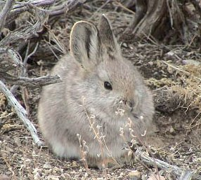

We are going to jump right into assembly! To start, let’s open up the terminal and navigate to the tutorial directory; it might look something like this:

```bash
cd /home/molecularecology/Downloads/nres721_assembly
```

Next, we should check out the directory structure in that folder using ‘ls’:

```bash
ls
```

```
## assembly_ed.Rmd
## assembly_final.Rmd
## assembly_old.Rmd
## assembly.Rmd
## BRACHYLAGUS_IDAHOENSIS.jpg
## data
## docs
## ipyrad_files
## reference
```

What folders do you see? We should have a data folder, an ipyrad folder, a reference folder, and a docs folder. Don’t worry about the docs folder - that is where this tutorial lives! In a similar fashion, don’t worry about the .Rmd file; that is the raw code I used to generate this tutorial. We will focus on the data folder for now.

These data are a small subset of a larger, previously-published 3RAD project, focusing on the adaptive potential and population genetics of pygmy rabbits in the southern Great Basin [(Byer et al. 2021)](https://onlinelibrary.wiley.com/doi/10.1111/mec.16040). This subset contains data from twenty individuals: five each from four collection localities. We can see these files in our `\data` directory:

```bash
ls ./data/*
```

```
./data/KBDC-B27_sub001_R1_.fastq
./data/KBDC-B27_sub001_R2_.fastq
./data/KBDC-B28_sub001_R1_.fastq
./data/KBDC-B28_sub001_R2_.fastq
./data/KBDC-B29_sub001_R1_.fastq
./data/KBDC-B29_sub001_R2_.fastq
./data/KBDC-B30_sub001_R1_.fastq
./data/KBDC-B30_sub001_R2_.fastq
./data/KBDC-B31_sub001_R1_.fastq
./data/KBDC-B31_sub001_R2_.fastq
./data/KJGB-B705_sub001_R1_.fastq
./data/KJGB-B705_sub001_R2_.fastq
./data/KJGB-B706_sub001_R1_.fastq
./data/KJGB-B706_sub001_R2_.fastq
./data/KJGB-B707_sub001_R1_.fastq
./data/KJGB-B707_sub001_R2_.fastq
./data/KJGB-B708_sub001_R1_.fastq
./data/KJGB-B708_sub001_R2_.fastq
./data/KJGB-B709_sub001_R1_.fastq
./data/KJGB-B709_sub001_R2_.fastq
./data/KWGA-B202_sub001_R1_.fastq
./data/KWGA-B202_sub001_R2_.fastq
./data/KWGA-B203_sub001_R1_.fastq
./data/KWGA-B203_sub001_R2_.fastq
./data/KWGA-B204_sub001_R1_.fastq
./data/KWGA-B204_sub001_R2_.fastq
./data/KWGA-B206_sub001_R1_.fastq
./data/KWGA-B206_sub001_R2_.fastq
./data/KWGA-B207_sub001_R1_.fastq
./data/KWGA-B207_sub001_R2_.fastq
./data/OIV-B126_sub001_R1_.fastq
./data/OIV-B126_sub001_R2_.fastq
./data/OIV-B127_sub001_R1_.fastq
./data/OIV-B127_sub001_R2_.fastq
./data/OIV-B128_sub001_R1_.fastq
./data/OIV-B128_sub001_R2_.fastq
./data/OIV-B129_sub001_R1_.fastq
./data/OIV-B129_sub001_R2_.fastq
./data/OIV-B12_sub001_R1_.fastq
./data/OIV-B12_sub001_R2_.fastq
```

There are a total of 40 files, consisting of a R1 and R2 file for each of the 20 samples. The first four letters of each sample name designates the sampling site of origin for that sample (KBDC = Bodie State Park, near the Mono Basin of California, KJGB = Jiggs, in eastern Nevada, KWGA = West Gulch, near the border between Nevada and Oregon, and OIV = Indian Valley, near central Nevada. These data have already been demultiplexed; the data for each sample has been subsetted down to 0.1% of its original read count to make things more manageable for you all!

## *De novo* assembly

**Note:** Today, we are going to use `ipyrad` to “call” genotypes. Some studies (e.g., [Gompert and Buerkle 2011](https://www.genetics.org/content/187/3/903?ijkey=db1c78ecc5d6122e25f7ddb64c0447c2fa3d6b32&keytype2=tf_ipsecsha); [Fumagalli et al. 2013](https://www.genetics.org/content/195/3/979)) have demonstrated the pitfalls of definitive genotype calling and instead strongly encourage the use of “genotype likelihoods”, which allow error in estimating genotypes to propogate through downstream analyses. For the sake of simplicity today, we will be calling (and later, using) called genotypes.

There are two general ways in which we can assemble these data in `ipyrad`: *de novo* and *reference*. In a *de novo* assembly, reads are clustered and aligned against other reads, and no reference genome is required. This is really great for non-model organisms for which reference genomes don’t exist! In the case of the pygmy rabbit, the Matocq lab recently generated a reference genome, which will allow us to compare and contrast *de novo* and *reference* assemblies. For our purposes today, we’re going to start by assembling these data *de novo*.

**Discussion:** What might the advantages be of assembling against a reference genome?

From within our working directory, we’ll initiate a new assembly called `bidaho_denovo` (and thus, create a parameters file) by first moving to the ipyrad_files directory and creating a new assembly. We can do so using the following code:

```bash
cd /home/molecularecology/Downloads/nres721_assembly/ipyrad_files
ipyrad -n bidaho_denovo
```

Let’s now look at this `ipyrad` parameters file:

```bash
cat params-bidaho_denovo.txt
```

[output not shown]

### steps 1 & 2

We’ll do this first assembly step-by-step and talk about the output. First, we’ll run step 1. **Note: By default, `ipyrad` will use all computer cores available, but you can set -c as needed to increase or decrease computational resources devoted to the assembly. Set these cautiously, though - and with a full awareness of the computational capabilities of your computer!**

```bash
ipyrad -p params-bidaho_denovo.txt -s 1 -d -f
```

```bash
cat bidaho_denovo_s1_demultiplex_stats.txt
```

```
                  reads_raw
KBDC-B27_sub001       33485
KBDC-B28_sub001       32716
KBDC-B29_sub001       34438
KBDC-B30_sub001       33514
KBDC-B31_sub001       45638
KJGB-B705_sub001      26488
KJGB-B706_sub001      27266
KJGB-B707_sub001      29557
KJGB-B708_sub001      27779
KJGB-B709_sub001      21123
KWGA-B202_sub001      31538
KWGA-B203_sub001      27132
KWGA-B204_sub001      18403
KWGA-B206_sub001      22965
KWGA-B207_sub001      22708
OIV-B126_sub001       49388
OIV-B127_sub001       49698
OIV-B128_sub001       36551
OIV-B129_sub001       27217
OIV-B12_sub001        25261
```

Next, we’ll run step 2.

```bash
ipyrad -p params-bidaho_denovo.txt -s 2 -d -f
```

```bash
cat bidaho_denovo_edits/s2_rawedit_stats.txt
```

```
                  reads_raw  trim_adapter_bp_read1  trim_adapter_bp_read2  trim_quality_bp_read1  trim_quality_bp_read2  reads_filtered_by_Ns  reads_filtered_by_minlen  reads_passed_filter
KBDC-B27_sub001       33485                   1369                   1293                   9732                  13097                     3                        34                33448
KBDC-B28_sub001       32716                   1374                   1202                   9761                  12270                     1                        26                32689
KBDC-B29_sub001       34438                   1410                   1288                  10429                  12673                     3                        39                34396
KBDC-B30_sub001       33514                   1164                   1173                  10623                  12361                     5                        25                33484
KBDC-B31_sub001       45638                   1658                   1482                  12458                  17275                    11                        37                45590
KJGB-B705_sub001      26488                   1121                   1082                   6835                  10001                     4                        32                26452
KJGB-B706_sub001      27266                   1106                   1099                   7586                  10527                     4                        23                27239
KJGB-B707_sub001      29557                   1203                   1194                   7614                  10034                     7                        19                29531
KJGB-B708_sub001      27779                   1091                   1053                   8609                  10282                     7                        33                27739
KJGB-B709_sub001      21123                    890                    856                   6320                   7088                     2                        12                21109
KWGA-B202_sub001      31538                   1355                   1370                   9251                  11521                     0                        22                31516
KWGA-B203_sub001      27132                   1255                   1260                   8359                  10028                     0                        21                27111
KWGA-B204_sub001      18403                    923                    838                   5297                   7059                     3                        15                18385
KWGA-B206_sub001      22965                   1059                   1042                   7050                   8268                     0                        21                22944
KWGA-B207_sub001      22708                   1007                    880                   6988                   8150                     6                        24                22678
OIV-B126_sub001       49388                   1879                   1822                  12446                  18108                     9                        36                49343
OIV-B127_sub001       49698                   2481                   2195                  13732                  18389                     6                        54                49638
OIV-B128_sub001       36551                   1480                   1401                  11430                  13105                    11                        33                36507
OIV-B129_sub001       27217                   1080                   1048                   8110                  10801                     1                        23                27193
OIV-B12_sub001        25261                   1244                   1129                   6587                   7683                     4                        20                25237
```

### step 3

Next, we’ll run step 3. This is the within-sample clustering step, in which the reads are compared against each other, clustered based on similarity into “loci”, and then aligned. This is a relatively computationally intensive step.

```bash
ipyrad -p params-bidaho_denovo.txt -s 3 -d -f
```

Once completed, we can view the results of this step in the `bidaho_denovo_clust_0.85/s3_cluster_stats.txt` file:

```bash
cat bidaho_denovo_clust_0.85/s3_cluster_stats.txt
```

```
                 clusters_total  hidepth_min clusters_hidepth avg_depth_total avg_depth_mj avg_depth_stat sd_depth_total sd_depth_mj sd_depth_stat
KBDC-B27_sub001           24202            3             1176            1.31         3.94          13.67           1.23        4.60         14.91
KBDC-B28_sub001           23819            3             1165            1.32         3.99          14.74           1.37        5.29         17.66
KBDC-B29_sub001           24771            3             1342            1.33         3.87          13.40           1.35        4.93         16.93
KBDC-B30_sub001           24064            3             1243            1.32         3.91          12.77           1.26        4.57         14.48
KBDC-B31_sub001           30087            3             2559            1.44         3.81          12.69           1.62        4.76         18.05
KJGB-B705_sub001          20162            3              710            1.26         4.08          11.23           1.00        4.08         10.13
KJGB-B706_sub001          20453            3              813            1.27         4.10          14.30           1.30        5.59         16.75
KJGB-B707_sub001          21829            3              969            1.30         4.02          15.14           1.36        5.54         18.34
KJGB-B708_sub001          20991            3              783            1.27         4.25          14.88           1.36        6.09         17.72
KJGB-B709_sub001          16755            3              456            1.21         4.45          16.61           1.29        6.81         18.71
KWGA-B202_sub001          23234            3              974            1.27         4.07          14.90           1.37        5.82         18.65
KWGA-B203_sub001          20410            3              743            1.26         4.06          14.83           1.15        4.95         14.68
KWGA-B204_sub001          14715            3              335            1.20         4.79          16.40           1.31        7.59         18.10
KWGA-B206_sub001          17905            3              517            1.23         4.22          15.37           1.10        5.38         14.47
KWGA-B207_sub001          17838            3              480            1.23         4.53          17.72           1.30        6.88         18.28
OIV-B126_sub001           32259            3             2617            1.44         3.93          14.78           2.01        6.41         24.45
OIV-B127_sub001           33555            3             2253            1.38         3.91          16.59           2.00        7.09         29.75
OIV-B128_sub001           26094            3             1291            1.33         4.12          16.89           1.75        7.12         25.09
OIV-B129_sub001           20214            3              792            1.26         3.95          14.69           1.11        4.57         14.52
OIV-B12_sub001            18825            3              571            1.24         4.64          12.13           1.15        5.28         10.72
```

**Discussion:** What can you glean from this output? What is the distribution of our sequencing coverage? What do you think might contribute to heterogeneity in sequencing coverage among and within samples?

### steps 4 & 5

Next, we’ll run steps 4 and 5 together. These steps estimate sequencing error rates, estimate genome-wide heterozygosity, and call consensus sequences for each individual for use in across-sample clustering.

```bash
ipyrad -p params-bidaho_denovo.txt -s 45 -d -f
```

We can view the results of step 4:

```bash
cat bidaho_denovo_clust_0.85/s4_joint_estimate.txt
```

```
                  hetero_est  error_est
KBDC-B27_sub001     0.032470   0.006654
KBDC-B28_sub001     0.037331   0.005313
KBDC-B29_sub001     0.032373   0.005578
KBDC-B30_sub001     0.026788   0.005459
KBDC-B31_sub001     0.028945   0.005753
KJGB-B705_sub001    0.031329   0.007840
KJGB-B706_sub001    0.035553   0.005943
KJGB-B707_sub001    0.035591   0.007048
KJGB-B708_sub001    0.035906   0.006667
KJGB-B709_sub001    0.034069   0.006501
KWGA-B202_sub001    0.038176   0.005566
KWGA-B203_sub001    0.037355   0.005841
KWGA-B204_sub001    0.030969   0.005815
KWGA-B206_sub001    0.023526   0.006482
KWGA-B207_sub001    0.030250   0.006112
OIV-B126_sub001     0.026524   0.005548
OIV-B127_sub001     0.028971   0.004938
OIV-B128_sub001     0.030606   0.006068
OIV-B129_sub001     0.021817   0.005612
OIV-B12_sub001      0.031496   0.007889
```

We can also view the results for step 5:

```bash
cat bidaho_denovo_consens/s5_consens_stats.txt
```

```
                 clusters_total filtered_by_depth filtered_by_maxH  filtered_by_maxAlleles filtered_by_maxN reads_consens nsites nhetero heterozygosity
KBDC-B27_sub001           24202             23026               12                      16                9          1139 322650     172        0.00053
KBDC-B28_sub001           23819             22654                8                      12               13          1132 320141     183        0.00057
KBDC-B29_sub001           24771             23429               13                      13                9          1307 367942     291        0.00079
KBDC-B30_sub001           24064             22821                7                      18               13          1205 336887     195        0.00058
KBDC-B31_sub001           30087             27528               20                      20               16          2503 700516     411        0.00059
KJGB-B705_sub001          20162             19452               14                      11                9           676 190305     142        0.00075
KJGB-B706_sub001          20453             19640               10                      14                7           782 221941     172        0.00077
KJGB-B707_sub001          21829             20860               10                      14               10           935 262385     189        0.00072
KJGB-B708_sub001          20991             20208                8                      17               12           746 211158     174        0.00082
KJGB-B709_sub001          16755             16299                7                       8                8           433 122774     148        0.00121
KWGA-B202_sub001          23234             22260               10                      16                6           942 260504     252        0.00097
KWGA-B203_sub001          20410             19667                8                      11                8           716 198895     167        0.00084
KWGA-B204_sub001          14715             14380                4                       8                9           314  86385      95        0.00110
KWGA-B206_sub001          17905             17388                5                       8               10           494 135929     119        0.00088
KWGA-B207_sub001          17838             17358                7                       8               12           453 127137     109        0.00086
OIV-B126_sub001           32259             29642               24                      28               18          2547 709878     465        0.00066
OIV-B127_sub001           33555             31302               10                      22               12          2209 611021     376        0.00062
OIV-B128_sub001           26094             24803               10                      15               10          1256 351729     247        0.00070
OIV-B129_sub001           20214             19422                5                       8                6           773 212963     171        0.00080
OIV-B12_sub001            18825             18254               12                      17               13           529 145927     184        0.00126
```

### step 6

Let’s proceed to step 6. This is another “clustering” step, but instead of clustering reads within individuals, we’re clustering loci across individuals. With many samples, this step can be computationally intensive, but it should run quite quickly for us.

```bash
ipyrad -p params-bidaho_denovo.txt -s 6 -d -f
```

### step 7

Finally, we’ll run step 7, in which loci are catalogued, and data are output into a variety of formats (e.g., VCF, PHYLIP, Structure, etc.) for downstream analysis.

```bash
ipyrad -p params-bidaho_denovo.txt -s 7 -d -f
```

This also produces a useful file (`bidaho_denovo_outfiles/bidaho_denovo_stats.txt`) with summary statistics, which looks like this:

```
## The number of loci caught by each filter.
## ipyrad API location: [assembly].stats_dfs.s7_filters

                           total_filters applied_order retained_loci
total_prefiltered_loci                 0             0          3716
filtered_by_rm_duplicates             21            21          3695
filtered_by_max_indels                56            56          3639
filtered_by_max_SNPs                   1             0          3639
filtered_by_max_shared_het            15            10          3629
filtered_by_min_sample              3444          3444           185
total_filtered_loci                 3537          3531           185


## The number of loci recovered for each Sample.
## ipyrad API location: [assembly].stats_dfs.s7_samples

                  sample_coverage
KBDC-B27_sub001                80
KBDC-B28_sub001                91
KBDC-B29_sub001                89
KBDC-B30_sub001                94
KBDC-B31_sub001               114
KJGB-B705_sub001               69
KJGB-B706_sub001               78
KJGB-B707_sub001               89
KJGB-B708_sub001               82
KJGB-B709_sub001               59
KWGA-B202_sub001               62
KWGA-B203_sub001               80
KWGA-B204_sub001               52
KWGA-B206_sub001               66
KWGA-B207_sub001               60
OIV-B126_sub001                95
OIV-B127_sub001                99
OIV-B128_sub001                84
OIV-B129_sub001                68
OIV-B12_sub001                 87


## The number of loci for which N taxa have data.
## ipyrad API location: [assembly].stats_dfs.s7_loci

    locus_coverage  sum_coverage
1                0             0
2                0             0
3                0             0
4                0             0
5               44            44
6               29            73
7               22            95
8               20           115
9                6           121
10              13           134
11               8           142
12              11           153
13              11           164
14               5           169
15               3           172
16               5           177
17               1           178
18               3           181
19               3           184
20               1           185


The distribution of SNPs (var and pis) per locus.
## var = Number of loci with n variable sites (pis + autapomorphies)
## pis = Number of loci with n parsimony informative site (minor allele in >1 sample)
## ipyrad API location: [assembly].stats_dfs.s7_snps
## The "reference" sample is included if present unless 'exclude_reference=True'

    var  sum_var  pis  sum_pis
0    16        0   45        0
1    15       15   26       26
2    25       65   32       90
3    22      131   27      171
4    18      203   14      227
5     9      248    8      267
6    12      320    4      291
7     7      369    5      326
8    10      449    6      374
9     9      530    3      401
10    2      550    1      411
11    4      594    3      444
12    6      666    4      492
13    8      770    2      518
14    2      798    0      518
15    4      858    2      548
16    1      874    0      548
17    2      908    1      565
18    0      908    1      583
19    0      908    0      583
20    1      928    0      583
21    3      991    1      604
22    2     1035    0      604
23    0     1035    0      604
24    1     1059    0      604
25    0     1059    0      604
26    1     1085    0      604
27    0     1085    0      604
28    0     1085    0      604
29    0     1085    0      604
30    0     1085    0      604
31    1     1116    0      604
32    0     1116    0      604
33    0     1116    0      604
34    1     1150    0      604
35    0     1150    0      604
36    2     1222    0      604
37    0     1222    0      604
38    0     1222    0      604
39    0     1222    0      604
40    0     1222    0      604
41    0     1222    0      604
42    0     1222    0      604
43    0     1222    0      604
44    0     1222    0      604
45    0     1222    0      604
46    0     1222    0      604
47    0     1222    0      604
48    0     1222    0      604
49    0     1222    0      604
50    0     1222    0      604
51    1     1273    0      604


## Final Sample stats summary
                  state  reads_raw  reads_passed_filter  clusters_total  clusters_hidepth  hetero_est  error_est  reads_consens  loci_in_assembly
KBDC-B27_sub001       7      33485                33448           24202              1176    0.032470   0.006654           1139                80
KBDC-B28_sub001       7      32716                32689           23819              1165    0.037331   0.005313           1132                91
KBDC-B29_sub001       7      34438                34396           24771              1342    0.032373   0.005578           1307                89
KBDC-B30_sub001       7      33514                33484           24064              1243    0.026788   0.005459           1205                94
KBDC-B31_sub001       7      45638                45590           30087              2559    0.028945   0.005753           2503               114
KJGB-B705_sub001      7      26488                26452           20162               710    0.031329   0.007840            676                69
KJGB-B706_sub001      7      27266                27239           20453               813    0.035553   0.005943            782                78
KJGB-B707_sub001      7      29557                29531           21829               969    0.035591   0.007048            935                89
KJGB-B708_sub001      7      27779                27739           20991               783    0.035906   0.006667            746                82
KJGB-B709_sub001      7      21123                21109           16755               456    0.034069   0.006501            433                59
KWGA-B202_sub001      7      31538                31516           23234               974    0.038176   0.005566            942                62
KWGA-B203_sub001      7      27132                27111           20410               743    0.037355   0.005841            716                80
KWGA-B204_sub001      7      18403                18385           14715               335    0.030969   0.005815            314                52
KWGA-B206_sub001      7      22965                22944           17905               517    0.023526   0.006482            494                66
KWGA-B207_sub001      7      22708                22678           17838               480    0.030250   0.006112            453                60
OIV-B126_sub001       7      49388                49343           32259              2617    0.026524   0.005548           2547                95
OIV-B127_sub001       7      49698                49638           33555              2253    0.028971   0.004938           2209                99
OIV-B128_sub001       7      36551                36507           26094              1291    0.030606   0.006068           1256                84
OIV-B129_sub001       7      27217                27193           20214               792    0.021817   0.005612            773                68
OIV-B12_sub001        7      25261                25237           18825               571    0.031496   0.007889            529                87


## Alignment matrix statistics:
sequence matrix size: (20, 50917), 57.13% missing sites.
snps matrix size: (20, 1273), 59.68% missing sites.
```

**Discussion:** Examine these summary statistics. At what steps are loci being filtered out? Is this indicative of any problems with our analysis or data?

## Reference-based assembly

**Discussion:** How might you predict that assembling against a reference genome will change the results of our assembly?

We have one such reference already prepared, and we can peek at this FASTA file:

```bash
head -n 10 reference/Brachylagus_DTG_Mito_sub01.fasta
```

[output not shown]

As with the FASTQ files before, I have subsampled this file for convenience.

**Discussion:** How is this reference formatted?

Given computational limitations (basically, processing the full reference takes quite a bit more computational power than we have available!) I have already run this reference-based assembly; let’s take a look at the parameters file for this reference assembly, though:

```bash
cat params-bidaho_reference.txt
```

```
## ------- ipyrad params file (v.0.9.81)-------------------------------------------
## bidaho_reference        ## [0] [assembly_name]: Assembly name. Used to name output directories for assembly steps
## /home/molecularecology/Downloads/nres721_assembly/ipyrad_files ## [1] [project_dir]: Project dir (made in curdir if not present)
##                                ## [2] [raw_fastq_path]: Location of raw non-demultiplexed fastq files
##                                ## [3] [barcodes_path]: Location of barcodes file
## /home/molecularecology/Downloads/nres721_assembly/data/*.fastq                                ## [4] [sorted_fastq_path]: Location of demultiplexed/sorted fastq files
## reference                        ## [5] [assembly_method]: Assembly method (denovo, reference)
## /home/molecularecology/Downloads/nres721_assembly/reference/Brachylagus_DTG_Mito.fasta                               ## [6] [reference_sequence]: Location of reference sequence file
## pair3rad                            ## [7] [datatype]: Datatype (see docs): rad, gbs, ddrad, etc.
## CTAGAT,AATTC,CTAGC                         ## [8] [restriction_overhang]: Restriction overhang (cut1,) or (cut1, cut2)
## 5                              ## [9] [max_low_qual_bases]: Max low quality base calls (Q<20) in a read
## 33                             ## [10] [phred_Qscore_offset]: phred Q score offset (33 is default and very standard)
## 6                              ## [11] [mindepth_statistical]: Min depth for statistical base calling
## 3                              ## [12] [mindepth_majrule]: Min depth for majority-rule base calling
## 10000                          ## [13] [maxdepth]: Max cluster depth within samples
## 0.85                           ## [14] [clust_threshold]: Clustering threshold for de novo assembly
## 0                              ## [15] [max_barcode_mismatch]: Max number of allowable mismatches in barcodes
## 2                              ## [16] [filter_adapters]: Filter for adapters/primers (1 or 2=stricter)
## 35                             ## [17] [filter_min_trim_len]: Min length of reads after adapter trim
## 2                              ## [18] [max_alleles_consens]: Max alleles per site in consensus sequences
## 0.05                           ## [19] [max_Ns_consens]: Max N's (uncalled bases) in consensus
## 0.05                           ## [20] [max_Hs_consens]: Max Hs (heterozygotes) in consensus
## 5                              ## [21] [min_samples_locus]: Min # samples per locus for output
## 0.2                            ## [22] [max_SNPs_locus]: Max # SNPs per locus
## 8                              ## [23] [max_Indels_locus]: Max # of indels per locus
## 0.5                            ## [24] [max_shared_Hs_locus]: Max # heterozygous sites per locus
## 0, 0, 0, 0                     ## [25] [trim_reads]: Trim raw read edges (R1>, <R1, R2>, <R2) (see docs)
## 0, 0, 0, 0                     ## [26] [trim_loci]: Trim locus edges (see docs) (R1>, <R1, R2>, <R2)
## *                       ## [27] [output_formats]: Output formats (see docs)
##                                ## [28] [pop_assign_file]: Path to population assignment file
##                                ## [29] [reference_as_filter]: Reads mapped to this reference are removed in step 3
```

**Discussion:** Do you notice any differences between this parameter file and the *de novo* parameter file?

```bash
ipyrad -p params-ubrucei_reference.txt -s 1234567
```

As before, we will walk through each step of the assembly - but rather than actually running this assembly, we will just inspect the stats files produced at each step!

**Discussion:** Before we dive in, let’s try to make some predictions about where we think these two assemblies will differ. Will it be:

1. during fastq editing (steps 1-2)
2. during initial clustering (step 3)
3. during error rate estimation and consensus calling (steps 4-5)
4. during final assembly steps (steps 6-7)?

You can pick more than one (or all) of these choices - but let’s make these predictions before we proceed!

### step 1

```bash
cat bidaho_reference_s1_demultiplex_stats.txt
```

```
                  reads_raw
KBDC-B27_sub001       33485
KBDC-B28_sub001       32716
KBDC-B29_sub001       34438
KBDC-B30_sub001       33514
KBDC-B31_sub001       45638
KJGB-B705_sub001      26488
KJGB-B706_sub001      27266
KJGB-B707_sub001      29557
KJGB-B708_sub001      27779
KJGB-B709_sub001      21123
KWGA-B202_sub001      31538
KWGA-B203_sub001      27132
KWGA-B204_sub001      18403
KWGA-B206_sub001      22965
KWGA-B207_sub001      22708
OIV-B126_sub001       49388
OIV-B127_sub001       49698
OIV-B128_sub001       36551
OIV-B129_sub001       27217
OIV-B12_sub001        25261
```

### step 2

```bash
cat bidaho_reference_edits/s2_rawedit_stats.txt
```

```
                  reads_raw  trim_adapter_bp_read1  trim_adapter_bp_read2  trim_quality_bp_read1  trim_quality_bp_read2  reads_filtered_by_Ns  reads_filtered_by_minlen  reads_passed_filter
KBDC-B27_sub001       33485                   1369                   1293                   9732                  13097                     3                        34                33448
KBDC-B28_sub001       32716                   1374                   1202                   9761                  12270                     1                        26                32689
KBDC-B29_sub001       34438                   1410                   1288                  10429                  12673                     3                        39                34396
KBDC-B30_sub001       33514                   1164                   1173                  10623                  12361                     5                        25                33484
KBDC-B31_sub001       45638                   1658                   1482                  12458                  17275                    11                        37                45590
KJGB-B705_sub001      26488                   1121                   1082                   6835                  10001                     4                        32                26452
KJGB-B706_sub001      27266                   1106                   1099                   7586                  10527                     4                        23                27239
KJGB-B707_sub001      29557                   1203                   1194                   7614                  10034                     7                        19                29531
KJGB-B708_sub001      27779                   1091                   1053                   8609                  10282                     7                        33                27739
KJGB-B709_sub001      21123                    890                    856                   6320                   7088                     2                        12                21109
KWGA-B202_sub001      31538                   1355                   1370                   9251                  11521                     0                        22                31516
KWGA-B203_sub001      27132                   1255                   1260                   8359                  10028                     0                        21                27111
KWGA-B204_sub001      18403                    923                    838                   5297                   7059                     3                        15                18385
KWGA-B206_sub001      22965                   1059                   1042                   7050                   8268                     0                        21                22944
KWGA-B207_sub001      22708                   1007                    880                   6988                   8150                     6                        24                22678
OIV-B126_sub001       49388                   1879                   1822                  12446                  18108                     9                        36                49343
OIV-B127_sub001       49698                   2481                   2195                  13732                  18389                     6                        54                49638
OIV-B128_sub001       36551                   1480                   1401                  11430                  13105                    11                        33                36507
OIV-B129_sub001       27217                   1080                   1048                   8110                  10801                     1                        23                27193
OIV-B12_sub001        25261                   1244                   1129                   6587                   7683                     4                        20                25237
```

### step 3

```bash
cat bidaho_reference_clust_0.85/s3_cluster_stats.txt
```

```
                 clusters_total  hidepth_min clusters_hidepth avg_depth_total avg_depth_mj avg_depth_stat sd_depth_total sd_depth_mj sd_depth_stat
KBDC-B27_sub001           20802            3             1349            1.38         3.83          14.30           1.33        4.31         15.58
KBDC-B28_sub001           20515            3             1332            1.38         3.81          15.32           1.31        4.20         15.90
KBDC-B29_sub001           21271            3             1490            1.39         3.75          15.06           1.32        4.10         16.23
KBDC-B30_sub001           21083            3             1441            1.39         3.85          15.82           1.41        4.53         17.08
KBDC-B31_sub001           25810            3             2841            1.53         3.78          12.31           1.50        3.64         13.83
KJGB-B705_sub001          17388            3              800            1.30         3.85          12.47           1.00        3.44          9.77
KJGB-B706_sub001          17893            3              947            1.32         3.81          14.34           1.08        3.59         11.09
KJGB-B707_sub001          18972            3             1085            1.34         3.73          14.06           1.06        3.31         11.61
KJGB-B708_sub001          18273            3              917            1.32         3.95          13.75           1.13        3.93         11.39
KJGB-B709_sub001          14642            3              482            1.24         4.05          15.69           1.05        4.66         13.39
KWGA-B202_sub001          20110            3             1148            1.35         4.09          17.36           1.51        5.42         17.66
KWGA-B203_sub001          17839            3              852            1.32         4.05          17.35           1.33        5.13         16.58
KWGA-B204_sub001          13140            3              360            1.23         4.65          18.56           1.39        7.36         18.93
KWGA-B206_sub001          15736            3              597            1.27         4.13          19.36           1.22        5.22         15.56
KWGA-B207_sub001          15683            3              563            1.27         4.14          16.45           1.21        5.36         15.44
OIV-B126_sub001           27970            3             3047            1.54         3.89          14.72           1.92        5.12         20.31
OIV-B127_sub001           28608            3             2709            1.49         3.87          15.60           1.99        5.80         24.66
OIV-B128_sub001           22570            3             1530            1.40         3.91          17.25           1.52        4.98         19.34
OIV-B129_sub001           17604            3              960            1.33         3.97          16.83           1.35        4.83         15.88
OIV-B12_sub001            16838            3              648            1.29         4.59          14.77           1.35        5.69         12.83
```

### step 4

```bash
cat bidaho_reference_clust_0.85/s4_joint_estimate.txt
```

```
                  hetero_est  error_est
KBDC-B27_sub001     0.017251   0.004482
KBDC-B28_sub001     0.020029   0.004723
KBDC-B29_sub001     0.016862   0.006017
KBDC-B30_sub001     0.016232   0.006093
KBDC-B31_sub001     0.012308   0.004895
KJGB-B705_sub001    0.017357   0.004460
KJGB-B706_sub001    0.023574   0.005273
KJGB-B707_sub001    0.020577   0.005456
KJGB-B708_sub001    0.018693   0.005282
KJGB-B709_sub001    0.021015   0.005954
KWGA-B202_sub001    0.018884   0.005662
KWGA-B203_sub001    0.018787   0.006680
KWGA-B204_sub001    0.020067   0.004702
KWGA-B206_sub001    0.023194   0.007367
KWGA-B207_sub001    0.020067   0.004552
OIV-B126_sub001     0.013822   0.004515
OIV-B127_sub001     0.013002   0.004522
OIV-B128_sub001     0.018192   0.004807
OIV-B129_sub001     0.016923   0.007306
OIV-B12_sub001      0.016787   0.005179
```

### step 5

```bash
cat bidaho_reference_consens/s5_consens_stats.txt
```

```
                 clusters_total filtered_by_depth filtered_by_maxH  filtered_by_maxAlleles filtered_by_maxN reads_consens nsites nhetero heterozygosity
KBDC-B27_sub001           20802             19531               20                      10                0          1098 311851     162        0.00052
KBDC-B28_sub001           20515             19250               21                       9                0          1089 306004     162        0.00053
KBDC-B29_sub001           21271             19851               23                       9                0          1231 345976     208        0.00060
KBDC-B30_sub001           21083             19717               22                      14                0          1189 327390     201        0.00061
KBDC-B31_sub001           25810             23100               46                      17                0          2418 669632     363        0.00054
KJGB-B705_sub001          17388             16638                7                       9                0           633 178019     109        0.00061
KJGB-B706_sub001          17893             17000               14                       8                0           772 218182     188        0.00086
KJGB-B707_sub001          18972             17948               20                       8                0           884 247312     139        0.00056
KJGB-B708_sub001          18273             17413               11                      11                0           731 206286     166        0.00080
KJGB-B709_sub001          14642             14177                6                       9                0           394 110587      98        0.00089
KWGA-B202_sub001          20110             19028               17                      13                0           918 249477     193        0.00077
KWGA-B203_sub001          17839             17047               16                       8                0           654 178395     138        0.00077
KWGA-B204_sub001          13140             12800                4                       7                0           287  77550      56        0.00072
KWGA-B206_sub001          15736             15178                7                       4                0           465 124975     103        0.00082
KWGA-B207_sub001          15683             15157                7                       7                0           437 121308      91        0.00075
OIV-B126_sub001           27970             25062               50                      21                0          2569 708522     427        0.00060
OIV-B127_sub001           28608             26045               55                      12                0          2215 605221     367        0.00061
OIV-B128_sub001           22570             21126               25                      11                0          1237 340745     178        0.00052
OIV-B129_sub001           17604             16696               21                      12                0           766 207557     132        0.00064
OIV-B12_sub001            16838             16233                9                      14                0           524 140122     151        0.00108
```

### step 7

```
## The number of loci caught by each filter.
## ipyrad API location: [assembly].stats_dfs.s7_filters

                           total_filters applied_order retained_loci
total_prefiltered_loci                 0             0         14212
filtered_by_rm_duplicates              0             0         14212
filtered_by_max_indels                 0             0         14212
filtered_by_max_SNPs                   0             0         14212
filtered_by_max_shared_het            11            11         14201
filtered_by_min_sample             13994         13994           207
total_filtered_loci                14005         14005           207


## The number of loci recovered for each Sample.
## ipyrad API location: [assembly].stats_dfs.s7_samples

                  sample_coverage
reference                     207
KBDC-B27_sub001                95
KBDC-B28_sub001                96
KBDC-B29_sub001                95
KBDC-B30_sub001               109
KBDC-B31_sub001               126
KJGB-B705_sub001               76
KJGB-B706_sub001               92
KJGB-B707_sub001               95
KJGB-B708_sub001               87
KJGB-B709_sub001               60
KWGA-B202_sub001               97
KWGA-B203_sub001               84
KWGA-B204_sub001               50
KWGA-B206_sub001               73
KWGA-B207_sub001               64
OIV-B126_sub001               116
OIV-B127_sub001               120
OIV-B128_sub001                98
OIV-B129_sub001                78
OIV-B12_sub001                102


```

[output cut: 86 more lines]

```
KWGA-B202_sub001      7      31538                31516                27103                   4413           20110              1148    0.018884   0.005662            918                97
KWGA-B203_sub001      7      27132                27111                23503                   3608           17839               852    0.018787   0.006680            654                84
KWGA-B204_sub001      7      18403                18385                16196                   2189           13140               360    0.020067   0.004702            287                50
KWGA-B206_sub001      7      22965                22944                20019                   2925           15736               597    0.023194   0.007367            465                73
KWGA-B207_sub001      7      22708                22678                19888                   2790           15683               563    0.020067   0.004552            437                64
OIV-B126_sub001       7      49388                49343                43062                   6281           27970              3047    0.013822   0.004515           2569               116
OIV-B127_sub001       7      49698                49638                42589                   7049           28608              2709    0.013002   0.004522           2215               120
OIV-B128_sub001       7      36551                36507                31578                   4929           22570              1530    0.018192   0.004807           1237                98
OIV-B129_sub001       7      27217                27193                23483                   3710           17604               960    0.016923   0.007306            766                78
OIV-B12_sub001        7      25261                25237                21657                   3580           16838               648    0.016787   0.005179            524               102


## Alignment matrix statistics:
snps matrix size: (21, 1453), 56.97% missing sites.
sequence matrix size: (21, 56945), 57.98% missing sites.
```

**Discussion:** You just completed your first RADseq assemblies! A few questions to consider as we conclude.

1. So - was your prediction right? Which steps differed between assemblies? Which steps were the same?
2. Based on your answer to 1., could you put into words what the relative advantages of reference-based assemblies might be?
3. Can you think of any scenarios when a *de novo* assembly may have advantages over reference assemblies?

Great job! In the next tutorial, we will learn about some basic population genomic and phylogenomic tools that we can use to answer questions based on post-assembly datasets.